# Rational approximation with the rSPDE package

David Bolin, Alexandre B. Simas, Zhen Xiong

2021-12-12

## Introduction

In this vignette we will illustrate how to do statistical inference with the covariance-based rational SPDE approach. The covariance-based rational approximation is related to the operator-based [rational approximation by Bolin and Kirchner (2020)](https://www.tandfonline.com/doi/full/10.1080/10618600.2019.1665537).

The covariance-based rational approximation is an efficient alternative to the operator-based rational approximation when one has SPDE driven by Gaussian white noise.

When dealing with fractional SPDE models driven by non-Gaussian white noises, the operator-based rational approximations might be useful. For instance, consider the SPDE:
$$L^{\alpha/2}(\tau u) = \widetilde{\mathcal{W}},$$
where $L = -\Delta +\kappa^2 I$ and $\widetilde{\mathcal{W}}$ is a non-Gaussian white noise. An example in which the operator-based rational approximation is suitable, is when one has the above SPDE with the white noise being the so-called type G Lévy noises.

We refer the reader to [Geostatistical Modelling Using Non-Gaussian Matérn Fields](https://onlinelibrary.wiley.com/doi/full/10.1111/sjos.12141), [Spatial Matérn Fields Driven by Non-Gaussian Noise](https://onlinelibrary.wiley.com/doi/abs/10.1111/sjos.12046) and [Linear mixed effects models for non-Gaussian continuous repeated measurement data](https://rss.onlinelibrary.wiley.com/doi/pdf/10.1111/rssc.12405) for examples of models driven by type-G Lévy noises. We also refer the reader to the [`ngme` package](https://github.com/davidbolin/ngme) where one can fit such models.

We explore the functions for performing the operator-based rational approximation on the vignette:

- Operator-based rational approximation with the rSPDE package

For the R-INLA implementation of the rational SPDE approach we refer the reader to the R-INLA implementation of the rational SPDE approach vignette.

## Covariance-based rational SPDE approach

Let us first present the basic setup. We want to model the precipitation as a two-dimensional random field $u$ within a bounded domain, where each location on the domain associates with a random variable which describe the local precipitation.

In the SPDE approach, we model $u$ as the solution of the following SPDE:
$$L^{\alpha/2}(\tau u) = \mathcal{W},$$
where $L = -\Delta +\kappa^2 I$ and $\mathcal{W}$ is the standard Gaussian white noise. Here, $\alpha$, $\kappa$ and $\tau$ are three parameters we want to estimate. In the standard SPDE approach, we write, for a general dimension $d$, $\alpha = \nu + d/2$ and assume $\nu$ to be fixed. In the rational SPDE approach we are able to estimate a general smoothness $\nu$ from the data.

Now let us briefly describe how covariance based rational SPDE approach works in statistical inference.

The central idea is to perform the rational approximation directly on the covariance operator, which is given by $L^{-\alpha}$, instead of on the solution $u$.

To this end, we begin by obtaining an approximation of the random field $u$, which is the solution of the SPDE written above, by using the finite element method (FEM):
$$u_h(\mathbf{s}_i)=\sum_{j=1}^{n_h} \hat{u}_j \varphi_j(\mathbf{s}_i),$$
where $\{\hat{u}_j\}_{j = 1}^{n_h}$ are stochastic weights and $\{\varphi_j(\mathbf{s}_i)\}_{j = 1}^{n_h}$ are fixed basis functions. We then obtain finite element approximation of the operator $L$, which is given by $L_h$, and the covariance operator of $u_h$ is given by $L_h^{-\alpha}$.

Now, by using the rational approximation on $L_h$, we can approximate covariance operator $L_h^{-\alpha}$ as
$$L_{h,m}^{-\alpha} = L_h^{-m_\alpha} p(L_h^{-1})q(L_h^{-1})^{-1},$$
where $m_{\alpha} = \lfloor\alpha\rfloor$, $m$ is the order of rational approximation, $p(L_h^{-1}) = \sum_{i=0}^m a_i L_h^{m-i}$ and $q(L_h^{-1}) = \sum_{j=0}^m b_j L_h^{m-i}$, with $\{a_i\}_{i = 0}^m$ and $\{b_j\}_{j = 0}^m$ are known coefficients obtained from the rational approximation.

The next step is to obtain the decomposition of $p(L_h^{-1})q(L_h^{-1})^{-1}$ into partial fractions to get the new representation:
$$L_{h,m}^{-\alpha} =L_h^{-m_\alpha} \left(\sum_{i=1}^{m} r_i (L_h-p_i I)^{-1} +k\right).$$
Based on the above operator equation, we can write covariance matrix of the stochastic weights $\hat{\textbf{u}}$, where $\hat{\textbf{u}}=[\hat{u}_1,...,\hat{u}_{n_h}]^\top$, as
$$\mathbf{\Sigma}_{\hat{\textbf{u}}} = (\textbf{L}^{-1}\textbf{C})^{m_{\alpha}} \sum_{i=1}^{m}r_i(\textbf{L}-p_i\textbf{C})^{-1}+\textbf{K},$$
where $\textbf{C} = \{C_{ij}\}_{i,j=1}^{n_h}$, $C_{ij} = (\varphi_i,\varphi_j)_{L_2(\mathcal{D})}$, is the mass matrix, $\textbf{L} = \kappa^2\textbf{C}+\textbf{G}$, $\textbf{G} = \{G_{ij}\}_{i,j=1}^{n_h}$, $G_{ij}=(\nabla\varphi_i,\nabla\varphi_j)_{L_2(\mathcal{D})}$, is the stiffness matrix, and
$$\textbf{K}=\left\{
\begin{array}{lcl}
k\textbf{C} & & {m_{\alpha}=0}\\
k\textbf{L}^{-1}(\textbf{C}\textbf{L}^{-1})^{m_{\alpha}-1} & & {m_{\alpha}>=1}\\
\end{array} \right.$$

The above representation shows that we can express $\hat{\textbf{u}}$ as
$$\hat{\textbf{u}}=\sum_{k=1}^{m+1}\textbf{x}_k,$$
where $\textbf{x}_k = (x_{k,1}, \ldots, x_{k,n_h})$,
$$\textbf{x}_i \sim N(\textbf{0},\textbf{Q}_i^{-1})$$
and $\textbf{Q}_i$ is the precision matrix of $\textbf{x}_i$, which is given by
$$\textbf{Q}_i=\left \{
\begin{array}{lcl}
(\textbf{L}-p_i\textbf{C})(\textbf{C}^{-1}\textbf{L})^{m_{\alpha}}/r_i, & & {i = 1,...,m}\\
\textbf{K}^{-1}, & & {i = m+1}\\
\end{array}. \right.$$

We, then, replace the Matérn latent field by the latent vector given above, which has precision matrix given by
$$\textbf{Q}=\begin{bmatrix}\textbf{Q}_1& &\\&\ddots&\\& &\textbf{Q}_{m+1}\end{bmatrix}.$$
Now, assume we observe
$$y_i = u_h(\mathbf{s}_i) + \varepsilon_i,\quad i=1,\ldots, N,$$
where $\varepsilon_i\sim N(0,\sigma_\varepsilon^2)$ are iid measurement noise. Then, we have that
$$y_i = u_h(\mathbf{s}_i) + \varepsilon_i = \sum_{j=1}^{n_h} \hat{u}_j \varphi_j(\mathbf{s}_i) + \varepsilon_i = \sum_{k=1}^{m+1} \sum_{j=1}^{n_h} x_{k,j} \varphi(\mathbf{s}_i) + \varepsilon_i.$$
This can be written in a matrix form as
$$\textbf{y} = \overline{\textbf{A}} \textbf{X} + \boldsymbol{\varepsilon},$$
where $\textbf{y} = [y_1,\ldots,y_N]^\top, \textbf{X} = [\textbf{x}_1^\top,\ldots,\textbf{x}_{m+1}^\top]^\top$, $\boldsymbol{\varepsilon} = [\varepsilon_1,\ldots,\varepsilon_N]^\top$,
$$\overline{\textbf{A}}=\begin{bmatrix}\textbf{A}&\cdots&\textbf{A}\end{bmatrix}_{n\times n_h(m+1)},$$
and
$$\textbf{A}=\begin{bmatrix}\varphi_1(s_1)&\cdots&\varphi_{n_h}(s_1)\\\vdots&\vdots&\vdots\\\varphi_1(s_n)&\cdots&\varphi_{n_h}(s_n)\end{bmatrix}.$$
We then arrive at the following hierarchical model:
$$\begin{align} \textbf{y}\mid \textbf{X} &\sim N(0,\sigma_\varepsilon\textbf{I})\\ \textbf{X}&\sim N(0,\textbf{Q}^{-1}) \end{align}.$$

With these elements, we can use INLA to compute the posterior distribution of the three parameters we want to estimate.

The covariance-based method has a computational advantage when compared to the standard rational approximation: the computational cost of a covariance-based rational approximation of order $m$ is approximately the same as the standard rational approximation of order $m/2$.

## Constructing the approximation

In this section, we explain how to to use the function `matern.operators()` with the default argument `type`, that is, `type="covariance"`, which is constructs the covariance-based rational approximation. We will also illustrate the usage of several methods and related functions related to the covariance-based rational approximation. We will use functions to sample from Gaussian fields with stationary Matérn covariance function, compute the log-likelihood function, perform predicitions (i.e., kringing), etc.

The first step for performing the covariance-based rational SPDE approximation is to define the FEM mesh. For illustration purposes, the `rSPDE` package contains a simple FEM implementation for models on $\mathbb{R}$ which we will use first. We will also illustrate how spatial models can be constructed, if the FEM implementation of the `R-INLA` package is used instead. When using the `R-INLA` package, we also recommend the usage of our `R-INLA` implementation of the rational SPDE approach. For more details see the R-INLA implementation of the rational SPDE approach vignette.

We begin by loading the `rSPDE` package:

```r
library(rSPDE)
```

Assume that we want to define a model on the interval $[0,1]$. We then start by defining a vector with mesh nodes $s_i$ where the basis functions $\varphi_i$ are centered.

```r
s <- seq(from = 0, to = 1, length.out = 101)
```

Based on these nodes, we use the built-in function `rSPDE.fem1d` to assemble two matrices needed for creating the approximation of a basic Matérn model. These matrices are the mass matrix $\boldsymbol{\mathrm{C}}$, with elements $C_{ij} = \int \varphi_j(s) \varphi_i(s) ds$, and the stiffness matrix $\boldsymbol{\mathrm{G}}$, with elements $G_{ij} = \int \nabla\varphi_j(s) \cdot \nabla\varphi_i(s) ds$.

```r
fem <- rSPDE.fem1d(s)
```

We can now use `matern.operators` to construct a rational SPDE approximation of order $m=2$ for a Gaussian random field with a Matérn covariance function on the interval. We also refer the reader to the Operator-based rational approximation with the `rSPDE` package for a similar comparison made for the operator-based rational approximation.

```r
kappa <- 20
sigma <- 2
nu <- 0.8
op_cov <- matern.operators(C=fem$C, G=fem$G,nu=nu,
                                   kappa=kappa,sigma=sigma,d=1,m=2)
```

The object `op_cov` contains the matrices needed for evaluating the distribution of the stochastic weights $\boldsymbol{\mathrm{u}}$. If we want to evaluate $u_h(s)$ at some locations $s_1,\ldots, s_n$, we need to multiply the weights with the basis functions $\varphi_i(s)$ evaluated at the locations. For this, we can construct the observation matrix $\boldsymbol{\mathrm{A}}$ with elements $A_{ij} = \varphi_j(s_i)$, linking the FEM basis functions to the locations. This matrix can be constructed using the function `rSPDE.A1d`. However, as observed in the introduction of this vignette, we have decomposed the stochastic weights $\boldsymbol{\mathrm{u}}$ into a vector of latent variables. Thus, the $A$ matrix for the covariance-based rational approximation, which we will denote by $\overline{A}$, is actually given by the $m+1$-fold horizontal concatenation of these $A$ matrices, where $m$ is the order of the rational approximation.

To compute the precision matrix from the covariance-based rational approximation one can use the `precision` method on the `CBrSPDEobj` object (the object returned by the `matern.operators()` function with the default type, which is `type="covariance"`):

```r
Q <- precision(op_cov)
```

To evaluate the accuracy of the approximation, let us compute the covariance function between the process at $s=0.5$ and all other locations in `s` and compare with the true Matérn covariance function. The covariances can be calculated as
$$\overline{\boldsymbol{\mathrm{A}}} \boldsymbol{\mathrm{Q}}^{-1}\overline{\boldsymbol{\mathrm{v}}}.$$
Here, $\boldsymbol{\mathrm{Q}}$ is the precision matrix obtained from the covariance-based rational approximation, $\boldsymbol{\mathrm{A}}$ is an identity matrix since we are evaluating the approximation in the nodes of the FEM mesh, $\overline{\boldsymbol{\mathrm{v}}}$ is the $(m+1)$-fold vertical concatenation of the vector $\boldsymbol{\mathrm{v}}$, where $\boldsymbol{\mathrm{v}}$ is a vector with all basis functions evaluated in $s=0.5$.

```r
v <- t(rSPDE.A1d(s,0.5))
v_bar <- kronecker(matrix(1,nrow=3),v)
A <- Diagonal(101)
A_bar <- kronecker(matrix(1,ncol=3),A)
c_cov.approx <- (A_bar)%*%solve(Q,v_bar)
```

Let us now compute the true Matérn covariance function on the interval $(0,1)$, which is the folded Matérn, see Theorem 1 in [An explicit link between Gaussian fields and Gaussian Markov random fields: the stochastic partial differential equation approach](https://www.jstor.org/stable/41262260) for further details.

```r
c.true <- folded.matern.covariance(rep(0.5,length(s)),abs(s), kappa, nu, sigma)
```

The covariance function and the error compared with the Matérn covariance are shown in the following figure.

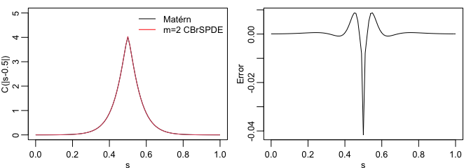

To improve the approximation we can increase the degree of the polynomials, by increasing $m$, and/or increase the number of basis functions used for the FEM approximation. Let us, for example, compute the approximation with $m=4$ using the same mesh, as well as the approximation when we increase the number of basis functions and use $m=2$ and $m=4$.

```r
op_cov2 <- matern.operators(kappa = kappa, sigma = sigma, nu = nu,
                       G = fem$G, C = fem$C, d = 1, m = 4)
Q2 <- precision(op_cov2)
v_bar2 <- kronecker(matrix(1,nrow=5),v)
A_bar2 <- kronecker(matrix(1,ncol=5),A)
c_cov.approx2 <- (A_bar2)%*%solve(Q2,v_bar2)

s2 <- seq(from = 0, to = 1, length.out = 501)
fem2 <- rSPDE.fem1d(s2)
op_cov <- matern.operators(kappa = kappa, sigma = sigma, nu = nu,
                       G = fem2$G, C = fem2$C, d = 1, m=2)
Q3 <- precision(op_cov)
A2 <- rSPDE.A1d(s2,s)
v2 <- t(rSPDE.A1d(s2,0.5))
v2_bar <- kronecker(matrix(1,nrow=3),v2)
A2_bar <- kronecker(matrix(1,ncol=3),A2)
c_cov.approx3 <- (A2_bar)%*%solve(Q3,v2_bar)

op_cov <- matern.operators(kappa = kappa, sigma = sigma, nu = nu,
                       G = fem2$G, C = fem2$C, d = 1, m=4)
Q4 <- precision(op_cov)
v2_bar2 <- kronecker(matrix(1,nrow=5),v2)
A2_bar2 <- kronecker(matrix(1,ncol=5),A2)
c_cov.approx4 <- (A2_bar2)%*%solve(Q4,v2_bar2)
```

The resulting errors are shown in the following figure.

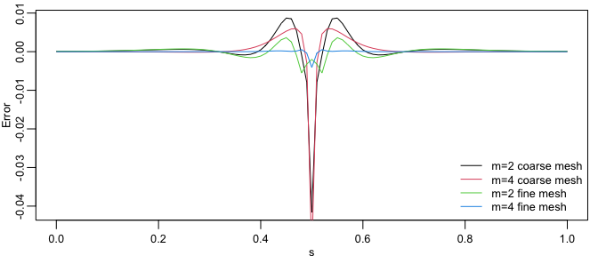

Since the error induced by the rational approximation decreases exponentially in $m$, there is in general rarely a need for an approximation with a large value of $m$. This is good because the size of $\boldsymbol{\mathrm{Q}}$ increases with $m$, which makes the approximation more computationally costly to use. To illustrate this, let us compute the norm of the approximation error for different $m$.

```r
errors <- rep(0,4)
for(i in 1:4){
  op_cov <- matern.operators(kappa = kappa, sigma=sigma, nu = nu,
                       G = fem2$G, C = fem2$C, d = 1, m = i)
  Q = precision(op_cov)
  v_bar <- kronecker(matrix(1,nrow=i+1),v2)
  A_bar <- kronecker(matrix(1,ncol=i+1),A2)
  c_cov.approx <- (A_bar)%*%solve(Q,v_bar)
  errors[i] <- norm(c.true-c_cov.approx)
}
print(errors)
```

```
## [1] 0.977500618 0.086659186 0.017335546 0.008432142
```

We see that the error decreases very fast when we increase $m$ from $1$ to $4$, without any numerical instability. This is an advantage of the covariance-based rational approximation when compared to the operator-based rational approximation. See Operator-based rational approximation with the `rSPDE` package for details on the numerical instability of the operator-based rational approximation.

The main reason for the numerical stability of the covariance-based method is that its clever decomposition of the latent field into a vector of random fields (see the introduction for further details) remove the need of higher order finite element matrices to have higher order rational approximations.

## Using the approximation

When we use the function `matern.operators()`, we can simulate from the model using the `simulate` method. To such an end we simply apply the simulate method to the object returned by the `matern.operators()` function:

```r
u <- simulate(op_cov)
```

If we want replicates, we simply set the argument `nsim` to the desired number of replicates. For instance, to generate two replicates of the model, we simply do:

```r
u.rep <- simulate(op_cov, nsim=2)
```

### Fitting a model

There is also built-in support for computing loglikelihood function and performing kriging prediction. To illustrate this, we use the simulation to create some noisy observations of the process. For this, we first construct the observation matrix linking the FEM basis functions to the locations where we want to simulate. We first randomly generate some observation locations and then construct the matrix.

```r
set.seed(1)
s <- seq(from = 0, to = 1, length.out = 501)
n.obs <- 200
obs.loc <- runif(n.obs)
fem <- rSPDE.fem1d(s)
A <- rSPDE.A1d(s, obs.loc)
```

We now generate the observations as $Y_i = u(s_i) + \varepsilon_i$, where $\varepsilon_i \sim N(0,\sigma_e^2)$ is Gaussian measurement noise. We will assume that the latent process has a Matérn covariance with $\kappa=20, \sigma=2$ and $\nu=0.8$:

```r
kappa <- 20
sigma <- 2
nu <- 0.8
op_cov <- matern.operators(C=fem$C, G=fem$G,nu=nu,
                                   kappa=kappa,sigma=sigma,d=1,m=2)
u <- simulate(op_cov)

sigma.e <- 0.3
Y <- as.vector(A %*% u + sigma.e * rnorm(n.obs))
```

Let us now fit the model. To this end we first must compute the loglikelihood function as function of the parameters we want to estimate. We define the loglikelihood function parametrized using the logarithm of each parameter to avoid constrained optimization.

```r
mlik_cov <- function(theta, Y, A, op_cov){
sigma = exp(theta[1])
kappa = exp(theta[2])
nu = exp(theta[3])
return(-rSPDE::rSPDE.matern.loglike(object = op_cov, Y=Y,
                                  A = A, user_kappa=kappa, user_sigma = sigma,
                                 user_nu=nu, sigma.e = exp(theta[4])))
}
```

We will now get suitable initial values for the optimization using the `get.inital.values.rSPDE()`. We then add an initial guess for `sigma.e`.

```r
theta0 <- c(get.inital.values.rSPDE(mesh.range = 1, dim = 1),
            log(0.1*sqrt(var(as.vector(Y)))))

start_time <- Sys.time()
theta <- optim(theta0, mlik_cov, Y = Y, A = A, op_cov = op_cov,
method = "L-BFGS-B")
end_time <- Sys.time()

time_optim <- end_time - start_time

print(data.frame(sigma = c(sigma,exp(theta$par[1])), kappa = c(kappa,exp(theta$par[2])),
                  nu = c(nu,exp(theta$par[3])), sigma.e = c(sigma.e,exp(theta$par[4])),
                  row.names = c("Truth","Estimates")))
```

```
##           sigma    kappa        nu  sigma.e
## Truth         2 20.00000 0.8000000 0.300000
## Estimates     1 16.67311 0.7811246 0.328456
```

```r
#Total time
print(time_optim)
```

```
## Time difference of 7.715401 secs
```

We can also speed up the optimization by using the `optimParallel()` function from the `optimParallel` package. To such an end, we simply replace the `optim` function by `optimParallel` and set the number of cores we want to use:

```r
library(optimParallel)

cl <- makeCluster(detectCores()-1)
setDefaultCluster(cl=cl)

start_time <- Sys.time()
theta_parallel <- optimParallel(theta0, mlik_cov,
                                               Y = Y, A = A,
                                               op_cov = op_cov)
end_time <- Sys.time()

time_optim <- end_time - start_time

print(data.frame(sigma = c(sigma,exp(theta_parallel$par[1])),
                 kappa = c(kappa,exp(theta_parallel$par[2])),
                  nu = c(nu,exp(theta_parallel$par[3])),
                 sigma.e = c(sigma.e,exp(theta_parallel$par[4])),
                  row.names = c("Truth","Estimates")))
```

```
##           sigma    kappa        nu  sigma.e
## Truth         2 20.00000 0.8000000 0.300000
## Estimates     1 16.67311 0.7811246 0.328456
```

```r
#Total time
print(time_optim)
```

```
## Time difference of 4.754655 secs
```

### Kringing

Finally, we compute the kriging prediction of the process $u$ at the locations in `s` based on these observations. To specify which locations that should be predicted, the argument `Aprd` is used. This argument should be an observation matrix that links the mesh locations to the prediction locations.

```r
A.krig <- rSPDE.A1d(s, s)
```

Let us update the `CBrSPDEobj` object (returned by the `matern.operators()` function) with the fitted parameters:

```r
sigma_est = exp(theta$par[1])
kappa_est = exp(theta$par[2])
nu_est = exp(theta$par[3])

op_cov <- update(op_cov, user_kappa=kappa_est,
                 user_sigma = sigma_est,
                 user_nu = nu_est)
```

We can now perform kringing with the `predict` method:

```r
u.krig <- predict(op_cov, A = A, Aprd = A.krig, Y = Y, sigma.e = sigma.e)
```

The process simulation, the observed data, and the kriging prediction are shown in the following figure.

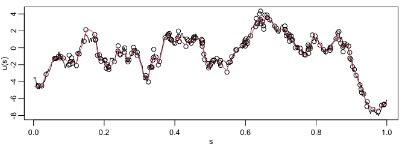

## Fitting a model with replicates

Let us illustrate how to simulate a dataset with replicates. Then, we will show how to fit and do kringing on such a dataset.

Recall that to simulate a latent model with replicates, all we do is set the `nsim` argument to the number of replicates.

Let us simulate the dataset. We will use the same `CBrSPDEobj` object (returned from the `matern.operators()` function) from the previous example, namely `op_cov`.

```r
set.seed(123)
n.rep = 20
u.rep <- simulate(op_cov, nsim=n.rep)
```

Now, let us generate the observed values $Y$:

```r
sigma.e <- 0.3
Y.rep <- A %*% u.rep + sigma.e * matrix(rnorm(n.obs*n.rep), ncol=n.rep)
```

```r
theta0 <- c(get.inital.values.rSPDE(mesh.range = 1, dim = 1),
            log(0.1*sqrt(var(as.vector(Y)))))

start_time <- Sys.time()
theta <- optimParallel(theta0, mlik_cov, Y = Y.rep, A = A, op_cov = op_cov,
method = "L-BFGS-B")
end_time <- Sys.time()

time_optim <- end_time - start_time

print(data.frame(sigma = c(sigma,exp(theta$par[1])), kappa = c(kappa,exp(theta$par[2])),
                  nu = c(nu,exp(theta$par[3])), sigma.e = c(sigma.e,exp(theta$par[4])),
                  row.names = c("Truth","Estimates")))
```

```
##           sigma    kappa        nu   sigma.e
## Truth         2 20.00000 0.8000000 0.3000000
## Estimates     1 17.26616 0.7824962 0.2954302
```

```r
#Total time
print(time_optim)
```

```
## Time difference of 2.354785 secs
```

## Spatial data and parameter estimation

The functions used in the previous examples also work for spatial models. We then need to construct a mesh over the domain of interest and then compute the matrices needed to define the operator. These tasks can be performed, for example, using the `R-INLA` package. Let us start by defining a mesh over $[0,1]\times [0, 1]$ and compute the mass and stiffness matrices for that mesh.

It is important to mention that when using the `R-INLA` package we recommend the usage of the R-INLA implementation of the rational SPDE approach.

Let us then consider a simple Gaussian linear model with 30 independent replicates of a latent spatial field $u(\mathbf{s})$, observed at the same $m$ locations, $\{\mathbf{s}_1 , \ldots , \mathbf{s}_m \}$, for each replicate. For each $i = 1,\ldots,m,$ we have

$$\begin{align}
y_i &= u_1(\mathbf{s}_i)+\varepsilon_i,\\
\vdots &= \vdots\\
y_{i+29m} &= u_{30}(\mathbf{s}_i) + \varepsilon_{i+29m},
\end{align}$$

where $\varepsilon_1,\ldots,\varepsilon_{30m}$ are iid normally distributed with mean 0 and standard deviation 0.1.

Let us then create the FEM mesh:

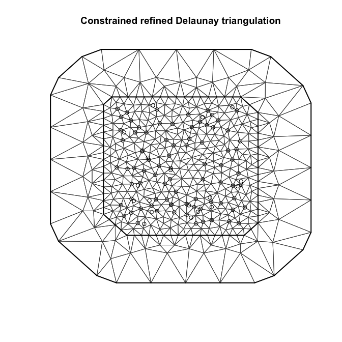

```r
library(INLA)
m =100
loc_2d_mesh = matrix(runif(m*2),m,2)
mesh_2d = inla.mesh.2d(
  loc=loc_2d_mesh,
  cutoff=0.05,
  offset=c(0.1,0.4),
  max.edge=c(0.05,0.5) )
plot(mesh_2d)
points(loc_2d_mesh[,1],loc_2d_mesh[,2])
```

We can now use this mesh to define a rational SPDE approximation of order $m=2$ for a Matérn model in the same fashion as we did above in the one-dimensional case. We will now simulate a latent process with standard deviation $\sigma=1$ and range $0.1$. We will use $\nu=0.5$ so that the model has an exponential covariance function. To this end we create a model object with the `matern.operators()` function:

```r
nu = 0.5
sigma = 1
range = 0.1
kappa = sqrt(8*nu)/range
d = 2
op_cov_2d = matern.operators(mesh=mesh_2d,
                                 nu=nu,
                                 kappa=kappa,
                                 sigma=sigma,
                                 m=2)
```

Now let us simulate some noisy data that we will use to estimate the parameters of the model. To construct the observation matrix, we use the `R-INLA` function `inla.spde.make.A()`. Recall that we will simulate the data with 30 replicates.

```r
n.rep = 30
u <- simulate(op_cov_2d, nsim=n.rep)
A <- inla.spde.make.A(
  mesh=mesh_2d,
  loc=loc_2d_mesh)
sigma.e <- 0.1
Y = A %*% u + matrix(rnorm(m*n.rep),ncol=n.rep) * sigma.e
```

The first replicate of the simulated random field as well as the observation locations are shown in the following figure.

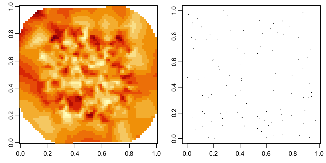

We will now use the function `rSPDE.matern.loglike()` to define the likelihood. This function is object-based, in the sense that it obtains several of the quantities it needs from the `rSPDE` model object. In our case, for this example, the object `op_cov_2d`.

To simplify parameter estimation, we create an objective function to maximize which is the negative log-likelihood, parametrized using the logarithm of each parameter to avoid constrained optimization.

```r
mlik_2d <- function(theta, Y, A, op_cov_2d) {
  sigma = exp(theta[1])
  kappa = exp(theta[2])
  nu = exp(theta[3])
  return(-rSPDE::rSPDE.matern.loglike(object = op_cov_2d, Y=Y,
                                  A = A, user_kappa=kappa, user_sigma = sigma,
                                 user_nu=nu, sigma.e = exp(theta[4])))
}
```

We can now estimate the parameter using `optimParallel`:

```r
theta0_2d = c(get.inital.values.rSPDE(mesh=mesh_2d),
              log(0.1*sqrt(var(as.vector(Y)))))
start_time <- Sys.time()
pars <- optimParallel(theta0_2d, mlik_2d, Y = Y, A = A, op_cov_2d=op_cov_2d)
end_time <- Sys.time()
total_time <- end_time - start_time
results <- data.frame(sigma = c(sigma, exp(pars$par[1])),
                      kappa = c(kappa, exp(pars$par[2])),
                      nu = c(nu, exp(pars$par[3])),
                      sigma.e = c(sigma.e, exp(pars$par[4])),
                      row.names = c("True", "Estimate"))
print(results)
```

```
##          sigma    kappa        nu   sigma.e
## True         1 20.00000 0.5000000 0.1000000
## Estimate     1 19.37055 0.5084295 0.1098874
```

```r
#Total time
print(total_time)
```

```
## Time difference of 12.46666 secs
```

## References

Bolin, David, and Kristin Kirchner. 2020. “The Rational SPDE Approach for Gaussian Random Fields with General Smoothness.” *Journal of Computational and Graphical Statistics* 29 (2): 274–85.

Lindgren, Finn, Håvard Rue, and Johan Lindström. 2011. “An Explicit Link Between Gaussian Fields and Gaussian Markov Random Fields: The Stochastic Partial Differential Equation Approach.” *Journal of the Royal Statistical Society. Series B. Statistical Methodology* 73 (4): 423–98.